# Assignment 1: Geospatial Data Science

# $\color{darkblue}{\text{Paper 4}}$

Paper: “In harm’s way? infrastructure investments and the persistence of coastal cities”.

Notes on the possible sources of data for figure 4 (“Road maps of Vietnam, 2000 and 2010”): - Replication package for paper 4: https://www.openicpsr.org/openicpsr/project/207641/version/V1/view. Useful information in: - Raw data -> Boundaries (for constructing Vietnam’s coastline as shown in the paper). - The author says that they were constructed using Natural Earth Data and then cropping the shapefile to include only Vietnam’s coastline. - But their files don’t include the boundaries of the whole Vietnam! So the replication package is not very useful. - Vietnam’s country boundaries obtained from: https://gadm.org/download_country.html. Different shape files for different territorial administrative levels. - Vietnam’s road network information (for 2015) obtained from: https://data.humdata.org/dataset/viet-nam-roads

#### 1. Relevant information of the paper for replicating the map

1. Maps to be replicated: road network of Vietnam in 2000 and 2010.
2. Need map of Vietnam.
3. Need road networks by road type (if they are available). On how the author constructed Vietnam’s road network:
- “I obtain road network data from the 2000 and 2010 editions of ITMB Publishing’s detailed International Travel Maps of Vietnam, which show the location of freeways, dual carriageways, major, minor and other roads.
- I geo-referenced each map and manually traced the location of each road category to obtain a GIS shapefile of the entire road network in each road category in 2000 and 2010, shown in Figure 3.”

#### 2.1. Vietnam’s boundaries

```r
sf_vietnam <- st_read(
  "gadm41_VNM_0.shp"
)
```

#### 2.2. Road network

```r
sf_vietnam_roads <- st_read(
  "vnm_rdsl_2015_0SM.shp"
)
str(sf_vietnam_roads)
```

```
## Classes 'sf' and 'data.frame':   118138 obs. of  6 variables:
##  $ osm_id    : chr  "9566542" "9656653" "9656730" "9963509" ...
##  $ name      : chr  "C?u Thê Húc" "Mã Mây" "C?u Chuong Duong" "Hàng Cót" ...
##  $ ref       : chr  NA NA NA NA ...
##  $ type      : chr  "footway" "residential" "primary" "secondary" ...
##  $ Shape_Leng: num  0.000413 0.002599 0.011551 0.001603 0.001613 ...
##  $ geometry  :sfc_MULTILINESTRING of length 118138; first list element: List of 1
##   ..$ : num [1:2, 1:2] 106 106 21 21
##   ..- attr(*, "class")= chr [1:3] "XY" "MULTILINESTRING" "sfg"
##  - attr(*, "sf_column")= chr "geometry"
##  - attr(*, "agr")= Factor w/ 3 levels "constant","aggregate",..: NA NA NA NA NA
##   ..- attr(*, "names")= chr [1:5] "osm_id" "name" "ref" "type" ...
```

```r
unique(sf_vietnam_roads$type)
```

```
##  [1] "footway"        "residential"    "primary"        "secondary"
##  [5] "pedestrian"     "tertiary"       "trunk"          "unclassified"
##  [9] "service"        "motorway_link"  "motorway"       "primary_link"
## [13] "track"          "tertiary_link"  "road"           "trunk_link"
## [17] "secondary_link" "living_street"  "steps"          "path"
## [21] "construction"   "cycleway"       "proposed"       "crossing"
## [25] "services"       "rest_area"      "yes"
```

We can map this renaming into the simple features dataset:

```r
road_type_mapping <- c(
  "motorway" = "Dual carriageway/Freeway",
  "motorway_link" = "Dual carriageway/Freeway",
  "trunk" = "Dual carriageway/Freeway",
  "trunk_link" = "Dual carriageway/Freeway",
  "primary" = "Major road",
  "primary_link" = "Major road",
  "secondary" = "Minor road",
  "secondary_link" = "Minor road",
  "tertiary" = "Minor road",
  "tertiary_link" = "Minor road",
  # All others are mapped to "Other"
  "footway" = "Other",
  "residential" = "Other",
  "pedestrian" = "Other",
  "unclassified" = "Other",
  "service" = "Other",
  "track" = "Other",
  "road" = "Other",
  "living_street" = "Other",
  "steps" = "Other",
  "path" = "Other",
  "construction" = "Other",
  "cycleway" = "Other",
  "proposed" = "Other",
  "crossing" = "Other",
  "services" = "Other",
  "rest_area" = "Other",
  "yes" = "Other"
)

sf_vietnam_roads <- sf_vietnam_roads %>%
  mutate(mapped_type = recode(type, !!!road_type_mapping))

unique(sf_vietnam_roads$mapped_type)
```

```
## [1] "Other"                    "Major road"
## [3] "Minor road"               "Dual carriageway/Freeway"
```

#### 3. Map replication

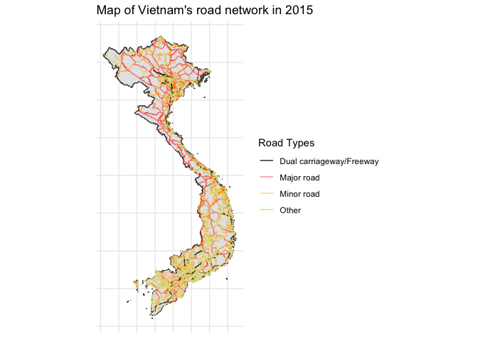

```r
ggplot() +
  geom_sf(data = sf_vietnam) +
  geom_sf(data = sf_vietnam_roads, aes(color = mapped_type)) +
  scale_color_manual(
    name = "Road Types",
    values = c(
      "Dual carriageway/Freeway" = "#213921",
      "Major road" = "#ff000074",
      "Minor road" = "#ffa60075",
      "Other" = "#e1e193"
    )
  ) +
  labs(
    title = "Map of Vietnam's road network in 2015"
  ) +
 theme_minimal() +
   theme(
    axis.text = element_blank()
  )
```

# $\color{darkblue}{\text{Paper 5}}$

Paper: “The Effects of Roads on Trade and Migration: Evidence from a Planned Capital City” The following analysis identifies radial and non-radial highways in Brazil, using Brasília as a central point. The roads are classified based on proximity to Brasília and visualized on a map.

We use data from the Instituto Brasileiro de Geografia e Estatística (Brazilian Institute of Geography and Statistics), which is responsible for the official collection of statistical, geographic, cartographic, geodetic, and environmental information in Brazil. The road dataset represents the main structuring road axes of the Brazilian territory. Additionally, we use the world map data and filter it to include only Brazil.

### Load Datasets

```r
# Load road dataset
road <- st_read("eixo_rodoviario_estruturante_2014.shp") %>%
  rename(
    SegmentDescription = DescSeg,
    RoadType = TipoPNV,
    Code = CODIGO
  )
head(road)
```

[output not shown]

```r
# We filter for Brazil from the world dataset
brazil <- world %>%
  filter(name_long == "Brazil")
# We select the cities highlight on fig. 1 in the paper
selected_cities <- c("Boa Vista", "Macapá", "Belém", "Manaus", "Porto Velho",
                     "Rio Branco", "Palmas", "Brasília",
                     "Cuiabá", "Campo Grande",
                     "São Paulo", "Rio de Janeiro", "Belo Horizonte",
                     "Florianópolis", "Porto Alegre", "Salvador", "Recife",
                     "Natal", "Fortaleza", "João Pessoa",
                     "Aracaju", "Maceió", "Goiânia", "Vitória")
# we filter for the year 2000 as indicated in fig. 1 in the paper
cities <- read_municipality(year = 2000) %>%
  filter(name_muni %in% selected_cities)
```

We use Brasília as the center point as the paper states “The roads radiating out from Brasília are known as radial highways” (Morten & Oliveira, 2018). Moreover, we are making sure that the point representing Brasília is in the same CRS as the road dataset. This is important because as seen in class the spatial operations like calculating distances will only work correctly if both the point and the roads use the same CRS.

```r
# Brasília coordinates
brasilia_coords <- cities %>%
  filter(name_muni == "Brasília") %>%
  st_coordinates()

# Brasília as a point in the same CRS as the roads dataset
brasilia_point <- st_sfc(
  st_point(c(brasilia_coords[1, "X"], brasilia_coords[1, "Y"])),
  crs = st_crs(road)
)

# We classify roads as Radial or Non-Radial based on distance from Brasília.
# We use a threshold of 500 to try to get as close to the figure as possible.
road <- road %>%
  mutate(
    distance_km = as.numeric(st_distance(geometry, brasilia_point)) / 1000,
    classification = ifelse(distance_km < 500, "Radial highways (2000)",
                            "Non−radial highways (2000)")
  )
```

### Visualization

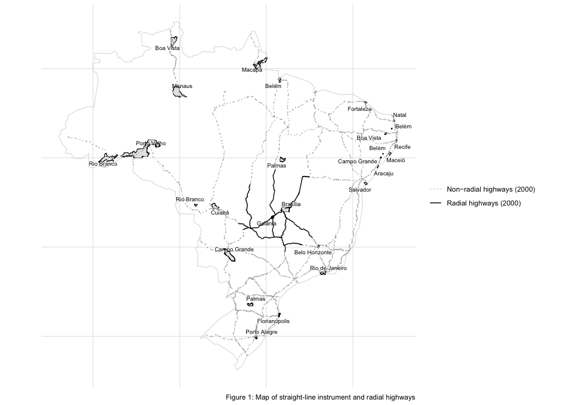

```r
ggplot() +
  geom_sf(data = brazil, fill = NA, color = "grey") +
  geom_sf(data = cities, size = 3, color = "black") +
  geom_text_repel(data = cities, aes(label = name_muni, geometry = geom),
                  stat = "sf_coordinates", size = 2.5) +
  geom_sf(data = road, aes(linetype = classification, color = classification),
          size = 0.5) +
  scale_linetype_manual(
    values = c("Radial highways (2000)" = "solid",
               "Non−radial highways (2000)" = "dotted")
  ) +
  scale_color_manual(
    values = c("Radial highways (2000)" = "black",
               "Non−radial highways (2000)" = "darkgrey")
  ) +
  theme_minimal() +
  theme(
    axis.title = element_blank(),
    axis.text = element_blank(),
    legend.title = element_blank()
  ) +
  labs(
    linetype = "Highway Type",
    color = "Highway Type",
    caption = "Figure 1: Map of straight-line instrument and radial highways"
  )
```

Note: We didn’t add the Minimum Spanning Tree (MST) road network because the method in the paper seems complex. It involves slicing the map, and finding the shortest paths from Brasília to state capitals in each slice and then combining those paths.

### References

Mettetal, E., 2019. Irrigation dams, water and infant mortality: Evidence from South Africa (fig. 2: hydro dams in South Africa)

Fried, S. and Lagakos, D., 2021. Rural electrification, migration and structural transformation: Evidence from Ethiopia (fig. 4: districts and electricity grid in Ethiopia)

Pellegrina, H.S. and Sotelo, S., 2021. Migration, Specialization, and Trade: Evidence from Brazil’s March to the West (fig. 2: Population in Brazil’s meso-regions (or districts) in different periods

Balboni, C.A., 2019. In harm’s way? infrastructure investments and the persistence of coastal cities. Link here (fig. 3: Vietnam’s road infrastructure by road type - if available)

Morten, M. & Oliveira, J., 2018. The Effects of Roads on Trade and Migration: Evidence from a Planned Capital City (fig. 1: Brazil’s capital and main road infrastructure)

### Data Sources

**Paper 1:**

Department of Water Affairs (Dam Safety Office):Department of Water Affairs. (2013). Dam Safety Office dataset. Retrieved from http://www.dwaf.gov.za/DSO/Default.aspx

Global Administrative Boundaries (Magisterial Districts): Global Administrative Boundaries. Magisterial district boundaries (pre-1996). Retrieved from https://hub.arcgis.com/datasets/nga::land-ownership/about?layer=34

AQUASTAT (FAO): Food and Agriculture Organization of the United Nations (FAO). (2025). AQUASTAT dams database. Retrieved from https://www.fao.org/aquastat/en/databases/dams/

**Paper 2:**

**Paper 3:**

**Paper 4:**

Replication Package for Paper 4: Balboni, C.A. Retrieved from https://www.openicpsr.org/openicpsr/project/207641/version/V1/view

Natural Earth Data (for Vietnam’s coastline):Natural Earth. Retrieved from https://www.naturalearthdata.com

Vietnam’s Country Boundaries: GADM. Retrieved from https://gadm.org/download_country.html

Vietnam’s Road Network (2015): United Nations Office for the Coordination of Humanitarian Affairs. (2015). Retrieved from https://data.humdata.org/dataset/viet-nam-roads

**Paper 5:**

Instituto Brasileiro de Geografia e Estatística. (2019). Transportation logistics. Retrieved from https://www.ibge.gov.br/en/geosciences/maps/brazil-geographic-networks-mapasdobrasil/18884-transportation-logistics.html